# Detection mode project: Tables and figures for publication

Author

Martina Brayley

Published

September 30, 2024

version 5 - Using data missing as a separate category in analysis

version 6 - swapping HRT variable for HRT subtypes variable

# 1 Table and figure structure:

**Main tables**

Table 1 - general descriptives (population characteristics)

Table 2 - Risk factor descriptives by detection mode with logistic regression results from default model ( adjusted for multiple exposures and selected covariates) + model additionally adjusted for mammo density (add mediation measure)

**Main figures**

Figures 1 to 3 - comprised figure of plots describing mamographic density in relation to risk factors (detail in ST 2)

**Supplementary material**

(ST = Supplementary Table)

ST 1 - TC descriptives by detection mode with logistic regression results for TC only + full model RF adjusting for TC + fulll RFmodel adjusting for TC and density

ST 2 - difference in characteristics between those with and without mammographic density

# 2 Main tables

## 2.1 Table 1 - general participant descriptives

stage coding - DCIS coded as stage 0 - should we keep it that way or code them as unknown? or DCIS?

time from recruitement to diagnosis categorical or continuous?

## 2.2 Updated table 1

by detection mode and with p-value from logistic regression model with tumour characteristics in the model (from supplementary table 1) + adjusted for time variables

| **Characteristic** | **I**, N = 755 <sup>1</sup> | **SD**, N = 1,185 <sup>1</sup> | **p-value** <sup>2</sup> |
| --- | --- | --- | --- |
| Age at diagnosis | 61.83 (6.79) | 61.11 (6.39) | 0.4 |
| Age at recruitment | 54.65 (7.10) | 54.69 (6.94) | 0.3 |
| Time from recruitment to diagnosis | 7.19 (3.69) | 6.42 (3.58) | 0.2 |
| Year of diagnosis |  |  |  |
| 2004-2008 | 96 (13) | 182 (15) |  |
| 2009-2013 | 255 (34) | 496 (42) | 0.3 |
| 2014-2018 | 404 (54) | 507 (43) | >0.9 |
| Invasive status |  |  |  |
| 0 | 47 (6.2) | 261 (22) |  |
| 1 | 708 (94) | 924 (78) | 0.082 |
| Grade |  |  |  |
| 1 | 88 (12) | 250 (21) |  |
| 2 | 335 (44) | 477 (40) | 0.006 |
| 3 | 264 (35) | 187 (16) | <0.001 |
| Missing | 68 (9.0) | 271 (23) | 0.026 |
| Morphology type |  |  |  |
| Ductal | 549 (73) | 698 (59) |  |
| Lobular | 95 (13) | 119 (10) | 0.8 |
| Mixed: ductal and other | 25 (3.3) | 43 (3.6) | 0.8 |
| Other | 39 (5.2) | 64 (5.4) | 0.7 |
| Missing | 47 (6.2) | 261 (22) |  |
| Positive nodes |  |  |  |
| Negative | 304 (40) | 601 (51) |  |
| Positive | 234 (31) | 194 (16) | <0.001 |
| Missing | 217 (29) | 390 (33) | <0.001 |
| Tumour size |  |  |  |
| <21 | 336 (45) | 656 (55) |  |
| 21-50 | 225 (30) | 162 (14) | <0.001 |
| 50+ | 31 (4.1) | 15 (1.3) | 0.004 |
| Missing | 163 (22) | 352 (30) | 0.009 |
| ER status |  |  |  |
| Positive | 525 (70) | 791 (67) |  |
| Negative | 137 (18) | 87 (7.3) | 0.006 |
| Missing | 93 (12) | 307 (26) | 0.7 |
| PR status |  |  |  |
| Positive | 283 (37) | 375 (32) |  |
| Negative | 175 (23) | 154 (13) | 0.3 |
| Missing | 297 (39) | 656 (55) | 0.016 |
| HER2 status |  |  |  |
| Positive | 102 (14) | 92 (7.8) |  |
| Negative | 524 (69) | 725 (61) | >0.9 |
| Missing | 129 (17) | 368 (31) | 0.8 |

<sup>1</sup> Mean (SD); n (%)  
<sup>2</sup> p-value from logistic regression multivariate model of all listed variables

## 2.3 Table 2 - Main analysis

The main analysis is a logistic regression with multiple exposures (risk factors).

This table shows risk factor level descriptives and their associations with the mode of detection (logistic regression) adjusted for all other risk factors, age at diagnosis and time from entry to BC diagnosis.

Model 2 is the final selected model (Default model) to present in the analysis. Model 2 is adjusted for all co-exposures + age at diagnosis and time from entry to BC diagnosis. Model 1 was only adjusted for co-exposures, e.i. all exposures in the model.

Because model 2 was selected as the default model, it is also used on the subanalyses with TC and MD as the comparison against adjusted models for TC and MD.

**Model 1**: “d_R1alcohol_status_cat”, “d_R1alcohol_units_cat”, “d_R1smokingstatus_cat”, “d_bmi_entry_cat”, “d_R1physmet_leis_who”, “d_bbd”, “d_fambrca”, “d_age_menarche_cat”, “d_ocstatus_cat”, “d_R1menopause_cat3”, “d_age_menopause_cat”, “d_R1hrtstatus_cat”, “d_parous_cat”, “d_parity_cat”, “d_agebirth1_cat”

**Model 2**: Model 1 + “diagage”, “d_R1toBC_y”, “yeardiag”

**Model 3:** Model 2 + “d_md_qrt”

**Model 4:** Model 3 + d_MDtoBC_lab (categorical)

[output not shown]

| **Characteristic** | **Distribution by detection mode** **I**, N = 755 <sup>1</sup> | **Distribution by detection mode** **SD**, N = 1,185 <sup>1</sup> | **Model 2** **OR** <sup>2,3</sup> | **Model 2** **95% CI** <sup>3</sup> | **Model 2** **p-value** | **Model 4** **OR** <sup>4,3</sup> | **Model 4** **95% CI** <sup>3</sup> | **Model 4** **p-value** |
| --- | --- | --- | --- | --- | --- | --- | --- | --- |
| Age at menarche |  |  |  |  |  |  |  |  |
| <12 | 153 (20) | 260 (22) | — | — |  | — | — |  |
| 12-13 | 369 (49) | 523 (44) | 1.17 | 0.91, 1.51 | 0.2 | 1.10 | 0.85, 1.43 | 0.5 |
| 14+ | 169 (22) | 286 (24) | 0.90 | 0.67, 1.20 | 0.5 | 0.85 | 0.63, 1.15 | 0.3 |
| Missing | 64 (8.5) | 116 (9.8) | 0.94 | 0.65, 1.37 | 0.8 | 0.84 | 0.57, 1.23 | 0.4 |
| Menopause |  |  |  |  |  |  |  |  |
| Premenopausal | 242 (32) | 355 (30) | — | — |  | — | — |  |
| Postmenopausal | 513 (68) | 830 (70) | 0.74 | 0.50, 1.09 | 0.13 | 0.79 | 0.53, 1.19 | 0.3 |
| Age at menopause |  |  |  |  |  |  |  |  |
| <50 | 116 (15) | 185 (16) | — | — |  | — | — |  |
| 50-54 | 332 (44) | 570 (48) | 0.88 | 0.67, 1.17 | 0.4 | 0.92 | 0.69, 1.24 | 0.6 |
| 55+ | 64 (8.5) | 71 (6.0) | 1.52 | 0.98, 2.36 | 0.060 | 1.58 | 1.01, 2.49 | 0.047 |
| Missing | 243 (32) | 359 (30) | 0.53 | 0.03, 3.85 | 0.6 | 1.11 | 0.05, 8.29 | >0.9 |
| HRT status |  |  |  |  |  |  |  |  |
| Never | 192 (25) | 354 (30) | — | — |  | — | — |  |
| Former | 161 (21) | 281 (24) | 1.03 | 0.78, 1.36 | 0.9 | 1.02 | 0.77, 1.36 | 0.9 |
| Current: Estrogen only | 63 (8.3) | 74 (6.2) | 1.64 | 1.10, 2.44 | 0.015 | 1.49 | 0.98, 2.24 | 0.059 |
| Current: Estrogen and progestogen | 82 (11) | 108 (9.1) | 1.34 | 0.93, 1.92 | 0.11 | 1.20 | 0.83, 1.73 | 0.3 |
| Current: Other HRT | 12 (1.6) | 10 (0.8) | 2.14 | 0.87, 5.34 | 0.10 | 2.02 | 0.80, 5.24 | 0.14 |
| Missing | 245 (32) | 358 (30) | 1.03 | 0.20, 4.53 | >0.9 | 1.22 | 0.22, 5.81 | 0.8 |
| Oral contraceptives status |  |  |  |  |  |  |  |  |
| Never | 95 (13) | 182 (15) | — | — |  | — | — |  |
| Former | 639 (85) | 967 (82) | 1.23 | 0.92, 1.65 | 0.2 | 1.28 | 0.94, 1.73 | 0.11 |
| Current | 20 (2.6) | 34 (2.9) | 1.11 | 0.57, 2.13 | 0.8 | 1.07 | 0.54, 2.07 | 0.8 |
| Missing | 1 (0.1) | 2 (0.2) | 1.50 | 0.06, 18.1 | 0.8 | 1.53 | 0.06, 20.4 | 0.8 |
| N of parous pregnancies |  |  |  |  |  |  |  |  |
| 0 | 97 (13) | 161 (14) | — | — |  | — | — |  |
| 1 | 86 (11) | 125 (11) | 1.51 | 0.82, 2.77 | 0.2 | 1.69 | 0.90, 3.16 | 0.10 |
| 2 | 408 (54) | 630 (53) | 1.34 | 0.78, 2.31 | 0.3 | 1.46 | 0.83, 2.56 | 0.2 |
| 3+ | 164 (22) | 269 (23) | 1.30 | 0.75, 2.25 | 0.4 | 1.44 | 0.81, 2.54 | 0.2 |
| Age at first birth |  |  |  |  |  |  |  |  |
| <20 | 35 (4.6) | 45 (3.8) | — | — |  | — | — |  |
| 20-24 | 197 (26) | 308 (26) | 0.80 | 0.49, 1.32 | 0.4 | 0.76 | 0.45, 1.28 | 0.3 |
| 25-29 | 256 (34) | 421 (36) | 0.73 | 0.45, 1.19 | 0.2 | 0.69 | 0.42, 1.16 | 0.2 |
| 30-34 | 122 (16) | 174 (15) | 0.83 | 0.49, 1.42 | 0.5 | 0.81 | 0.47, 1.41 | 0.5 |
| 35+ | 46 (6.1) | 71 (6.0) | 0.77 | 0.41, 1.42 | 0.4 | 0.76 | 0.40, 1.43 | 0.4 |
| Missing | 99 (13) | 166 (14) | 0.48 | 0.06, 2.50 | 0.4 | 0.43 | 0.05, 2.37 | 0.4 |
| Benign breast disease |  |  |  |  |  |  |  |  |
| No | 467 (62) | 831 (70) | — | — |  | — | — |  |
| Yes | 288 (38) | 354 (30) | 1.45 | 1.19, 1.78 | <0.001 | 1.35 | 1.10, 1.67 | 0.004 |
| Family history of BC |  |  |  |  |  |  |  |  |
| No | 564 (75) | 931 (79) | — | — |  | — | — |  |
| Yes | 191 (25) | 254 (21) | 1.25 | 1.00, 1.56 | 0.049 | 1.25 | 0.99, 1.57 | 0.061 |
| BMI |  |  |  |  |  |  |  |  |
| <18.5 | 8 (1.1) | 3 (0.3) | 3.93 | 1.09, 18.5 | 0.050 | 5.12 | 1.34, 25.7 | 0.025 |
| 18.5-25 | 421 (56) | 550 (46) | — | — |  | — | — |  |
| 25-30 | 203 (27) | 405 (34) | 0.66 | 0.53, 0.83 | <0.001 | 0.72 | 0.57, 0.91 | 0.005 |
| 30+ | 116 (15) | 213 (18) | 0.76 | 0.58, 1.00 | 0.052 | 0.90 | 0.67, 1.20 | 0.5 |
| Missing | 7 (0.9) | 14 (1.2) | 0.67 | 0.24, 1.67 | 0.4 | 0.81 | 0.29, 2.05 | 0.7 |
| Physical Activity (WHO cat) |  |  |  |  |  |  |  |  |
| <9 | 153 (20) | 271 (23) | — | — |  | — | — |  |
| 9-17 | 145 (19) | 246 (21) | 1.03 | 0.77, 1.38 | 0.8 | 0.98 | 0.72, 1.33 | >0.9 |
| 18+ | 451 (60) | 660 (56) | 1.19 | 0.93, 1.52 | 0.2 | 1.15 | 0.89, 1.47 | 0.3 |
| Missing | 6 (0.8) | 8 (0.7) | 1.80 | 0.57, 5.42 | 0.3 | 1.69 | 0.52, 5.23 | 0.4 |
| Alcohol units |  |  |  |  |  |  |  |  |
| 0 | 149 (20) | 258 (22) | — | — |  | — | — |  |
| 1-9 | 200 (26) | 317 (27) | 1.04 | 0.78, 1.38 | 0.8 | 1.05 | 0.79, 1.40 | 0.7 |
| 10-19 | 208 (28) | 290 (24) | 1.19 | 0.89, 1.57 | 0.2 | 1.20 | 0.90, 1.61 | 0.2 |
| 20-29 | 126 (17) | 190 (16) | 1.01 | 0.73, 1.39 | >0.9 | 1.04 | 0.75, 1.45 | 0.8 |
| 30+ | 72 (9.5) | 130 (11) | 0.85 | 0.59, 1.24 | 0.4 | 0.88 | 0.60, 1.30 | 0.5 |
| Smoking status |  |  |  |  |  |  |  |  |
| Never | 453 (60) | 709 (60) | — | — |  | — | — |  |
| Former | 261 (35) | 392 (33) | 1.07 | 0.87, 1.32 | 0.5 | 1.10 | 0.88, 1.36 | 0.4 |
| Current | 41 (5.4) | 82 (6.9) | 0.78 | 0.51, 1.17 | 0.2 | 0.81 | 0.53, 1.22 | 0.3 |
| Missing | 0 (0) | 2 (0.2) | 0.00 |  | >0.9 | 0.00 |  | >0.9 |
| Mammographic density (quartiles) |  |  |  |  |  |  |  |  |
| 1 | 73 (9.7) | 225 (19) |  |  |  | — | — |  |
| 2 | 96 (13) | 202 (17) |  |  |  | 1.35 | 0.92, 1.99 | 0.12 |
| 3 | 105 (14) | 193 (16) |  |  |  | 1.62 | 1.10, 2.38 | 0.014 |
| 4 | 127 (17) | 170 (14) |  |  |  | 2.15 | 1.45, 3.21 | <0.001 |
| Missing | 354 (47) | 395 (33) |  |  |  | 1.59 | 1.10, 2.31 | 0.014 |

<sup>1</sup> n (%)  
<sup>2</sup> Model 2: Age at menarche, Menopause, Age at menopause, HRT status, Oral contraceptives status, N of parous pregnancies, Age at first birth, Benign breast disease, Family history of BC, BMI at entry, Leisure Physical Activity (MET-h/w), Alcohol units per week, Smoking status, Age at Diagnosis, Time from Recruitment to BC diagnosis, Year of diagnosis  
<sup>3</sup> OR = Odds Ratio, CI = Confidence Interval  
<sup>4</sup> Model 4: Age at menarche, Menopause, Age at menopause, HRT status, Oral contraceptives status, N of parous pregnancies, Age at first birth, Benign breast disease, Family history of BC, BMI at entry, Leisure Physical Activity (MET-h/w), Alcohol units per week, Smoking status, Age at Diagnosis, Time from Recruitment to BC diagnosis, Year of diagnosis Percent Mammographic density (quartiles), Time from Mammographic density measurement to BRCA diagnosis.

# 3 Main figures

#### 3.1.0.1 Data transformation - formal statistical test of differences between categories

29/07/2024 decided to use square root transformation as data not normally distributed. Linear regression is then used to and p-values (what about estimate?) will be then added to the figures.

**Question**

Should the transformed estimate also be presented in the figures? Not sure how useful that will be as interpretation may be difficult due to the transformation. To solve this:

Option1: backtransform the estimate but complicated as need to back transform the CI or variance as well, claculations would have to be done for each chart individually. Problems with interpretation and explanations potentially

Option 2: present p-values on the figures, explain in footnote that it was done on transformed data and present linear regression results in the supplement - if anyone wants to backgtransform they can then do it themselves - more transparent

#### 3.1.0.2 Distribution before and after transformation

Figure for internal info only - data approximately normally distributed with more symmetry (checked with Michael and agreed this is appropriate for linear regression)

Notes: full code with more formal tests and distribution descriptives is in general_descriptives.qmd file

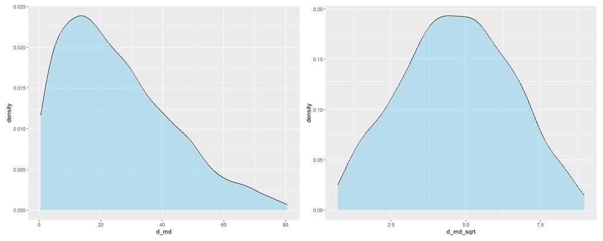

**Note**

### 3.1.1 Reproductive, lifestyle and other risk factors

plot list: plot 1 - detection mode plot 2 - Meno status plot 3 - age meno plot 4 - HRT plot 5 - n of parous preg plot 6 - age at first birth plot 7 - Age at menarche plot 8 - Oral contraceptives plot 9 - BBD plot 10 - Family history of BC plot 11 - Alcohol plot 12 - Smoking status plot 13 - BMI plot 14 - physical activity

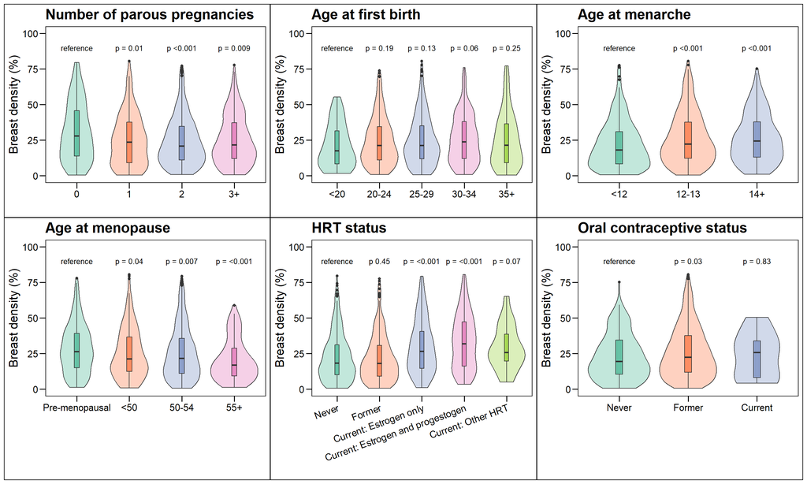

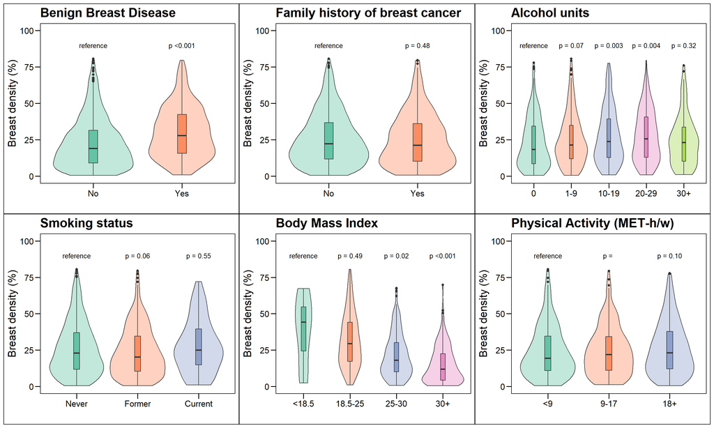

### 3.1.2 Tumour characteristics

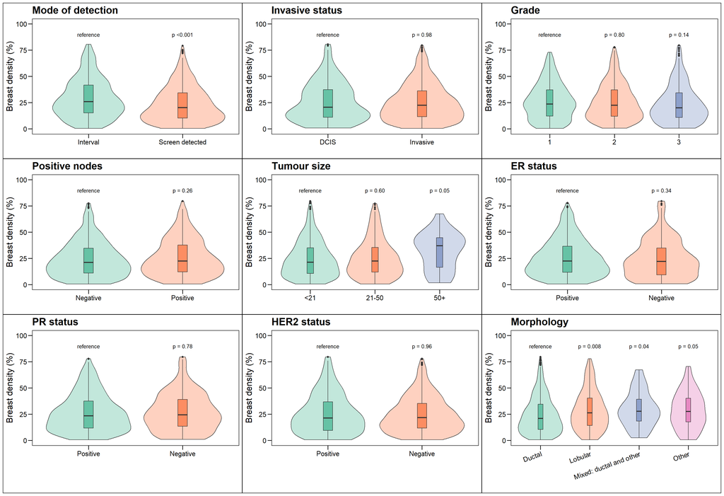

# 4 Supplementary material

## 4.1 ST 1 - TC descriptives and association with detection mode

TC descriptives by detection mode, logistic regression of TC with detection mode (same principal as risk factor analysis but multiple exposures are TC)

**Note**

this will be in excel format in supplement

| **Characteristic** | **Distribution by detection mode** **I**, N = 755 <sup>1</sup> | **Distribution by detection mode** **SD**, N = 1,185 <sup>1</sup> | **Model: TC only** **OR** <sup>2</sup> | **Model: TC only** **95% CI** <sup>2</sup> | **Model: TC only** **p-value** | **Model: TC + RF + time variables** **OR** <sup>2</sup> | **Model: TC + RF + time variables** **95% CI** <sup>2</sup> | **Model: TC + RF + time variables** **p-value** | **Model: TC + RF + MD + time variables** **OR** <sup>2</sup> | **Model: TC + RF + MD + time variables** **95% CI** <sup>2</sup> | **Model: TC + RF + MD + time variables** **p-value** |
| --- | --- | --- | --- | --- | --- | --- | --- | --- | --- | --- | --- |
| Invasive status |  |  |  |  |  |  |  |  |  |  |  |
| 0 | 47 (6.2) | 261 (22) | — | — |  | — | — |  | — | — |  |
| 1 | 708 (94) | 924 (78) | 1.56 | 0.90, 2.71 | 0.11 | 1.58 | 0.89, 2.81 | 0.12 | 1.64 | 0.91, 2.95 | 0.10 |
| Grade |  |  |  |  |  |  |  |  |  |  |  |
| 1 | 88 (12) | 250 (21) | — | — |  | — | — |  | — | — |  |
| 2 | 335 (44) | 477 (40) | 1.56 | 1.15, 2.12 | 0.004 | 1.62 | 1.18, 2.24 | 0.003 | 1.65 | 1.20, 2.30 | 0.002 |
| 3 | 264 (35) | 187 (16) | 2.41 | 1.69, 3.45 | <0.001 | 2.85 | 1.97, 4.16 | <0.001 | 3.00 | 2.05, 4.41 | <0.001 |
| Missing | 68 (9.0) | 271 (23) | 2.52 | 1.09, 6.12 | 0.035 | 2.93 | 1.23, 7.35 | 0.018 | 2.78 | 1.15, 7.14 | 0.027 |
| Morphology type |  |  |  |  |  |  |  |  |  |  |  |
| Ductal | 549 (73) | 698 (59) | — | — |  | — | — |  | — | — |  |
| Lobular | 95 (13) | 119 (10) | 0.94 | 0.67, 1.31 | 0.7 | 0.95 | 0.67, 1.35 | 0.8 | 0.90 | 0.62, 1.28 | 0.6 |
| Mixed: ductal and other | 25 (3.3) | 43 (3.6) | 0.92 | 0.53, 1.55 | 0.7 | 0.92 | 0.52, 1.61 | 0.8 | 0.91 | 0.51, 1.61 | 0.7 |
| Other | 39 (5.2) | 64 (5.4) | 0.89 | 0.55, 1.43 | 0.6 | 0.91 | 0.55, 1.49 | 0.7 | 0.84 | 0.50, 1.39 | 0.5 |
| Missing | 47 (6.2) | 261 (22) |  |  |  |  |  |  |  |  |  |
| Positive nodes |  |  |  |  |  |  |  |  |  |  |  |
| Negative | 304 (40) | 601 (51) | — | — |  | — | — |  | — | — |  |
| Positive | 234 (31) | 194 (16) | 1.67 | 1.29, 2.16 | <0.001 | 1.90 | 1.45, 2.50 | <0.001 | 1.88 | 1.42, 2.49 | <0.001 |
| Missing | 217 (29) | 390 (33) | 2.20 | 1.63, 2.97 | <0.001 | 2.35 | 1.71, 3.23 | <0.001 | 2.43 | 1.75, 3.38 | <0.001 |
| Tumour size |  |  |  |  |  |  |  |  |  |  |  |
| <21 | 336 (45) | 656 (55) | — | — |  | — | — |  | — | — |  |
| 21-50 | 225 (30) | 162 (14) | 2.12 | 1.63, 2.76 | <0.001 | 2.00 | 1.51, 2.64 | <0.001 | 2.05 | 1.54, 2.72 | <0.001 |
| 50+ | 31 (4.1) | 15 (1.3) | 3.11 | 1.60, 6.30 | 0.001 | 2.77 | 1.37, 5.79 | 0.005 | 2.65 | 1.30, 5.64 | 0.009 |
| Missing | 163 (22) | 352 (30) | 1.60 | 1.14, 2.27 | 0.007 | 1.60 | 1.11, 2.30 | 0.011 | 1.51 | 1.04, 2.19 | 0.031 |
| ER status |  |  |  |  |  |  |  |  |  |  |  |
| Positive | 525 (70) | 791 (67) | — | — |  | — | — |  | — | — |  |
| Negative | 137 (18) | 87 (7.3) | 1.68 | 1.14, 2.49 | 0.009 | 1.76 | 1.17, 2.65 | 0.007 | 1.67 | 1.10, 2.55 | 0.016 |
| Missing | 93 (12) | 307 (26) | 1.45 | 0.88, 2.37 | 0.14 | 1.12 | 0.67, 1.88 | 0.7 | 1.00 | 0.59, 1.69 | >0.9 |
| PR status |  |  |  |  |  |  |  |  |  |  |  |
| Positive | 283 (37) | 375 (32) | — | — |  | — | — |  | — | — |  |
| Negative | 175 (23) | 154 (13) | 0.86 | 0.61, 1.21 | 0.4 | 0.83 | 0.58, 1.19 | 0.3 | 0.78 | 0.54, 1.13 | 0.2 |

[output cut: 76 more lines]

<sup>1</sup> n (%)  
<sup>2</sup> OR = Odds Ratio, CI = Confidence Interval

## 4.2 ST 2 - Differences in characteristics between those with and without mammographic density

this table needs additional formatting changes, labels, add p-value for difference between groups, add time from entry to dg and age at diagnosis

any other variables to add or remove?

**Question**

Do we still need this table?

| **Characteristic** | **No**, N = 749 <sup>1</sup> | **Yes**, N = 1,191 <sup>1</sup> |
| --- | --- | --- |
| Mode of detection |  |  |
| I | 354 (47) | 401 (34) |
| SD | 395 (53) | 790 (66) |
| Menopause |  |  |
| Premenopausal | 364 (49) | 233 (20) |
| Postmenopausal | 385 (51) | 958 (80) |
| Age at menopause |  |  |
| <50 | 91 (12) | 210 (18) |
| 50-54 | 263 (35) | 639 (54) |
| 55+ | 31 (4.1) | 104 (8.7) |
| Missing | 364 (49) | 238 (20) |
| HRT status |  |  |
| Never | 162 (22) | 384 (32) |
| Former | 126 (17) | 316 (27) |
| Current: Estrogen only | 34 (4.5) | 103 (8.6) |
| Current: Estrogen and progestogen | 57 (7.6) | 133 (11) |
| Current: Other HRT | 4 (0.5) | 18 (1.5) |
| Missing | 366 (49) | 237 (20) |
| N of parous pregnancies |  |  |
| 0 | 104 (14) | 154 (13) |
| 1 | 74 (9.9) | 137 (12) |
| 2 | 410 (55) | 628 (53) |
| 3+ | 161 (21) | 272 (23) |
| Age at first birth |  |  |
| <20 | 32 (4.3) | 48 (4.0) |
| 20-24 | 177 (24) | 328 (28) |
| 25-29 | 270 (36) | 407 (34) |
| 30-34 | 117 (16) | 179 (15) |
| 35+ | 48 (6.4) | 69 (5.8) |
| Missing | 105 (14) | 160 (13) |

[output cut: 77 more lines]

<sup>1</sup> n (%); Mean (SD)